# 6. Analysis of longitudinal data

Since the question of most interest is “whether the growth profiles of the three groups differ” it would perhaps be most informative to examine summary statistics where the first group mean of rat weight is reduced from the final group mean of rat weight, in each group. Or examine with regression whether the rate of change in body weight differs between the groups. However, let’s just take the easiest route for now and do one summary graph with overall group means. We can account for the beginning weight in, for instance, Ancova (Analysis of covariance) later.

```r
# First, creating summaries of data by Group and ID with mean as the summary variable.
#
RATS_s2 <- RATS_l %>%
  group_by(Group, ID) %>%
  summarise(mean=mean(Weight)) %>%
  ungroup()

glimpse(RATS_s2)
```

```
## Rows: 16
## Columns: 3
## $ Group <fct> 1, 1, 1, 1, 1, 1, 1, 1, 2, 2, 2, 2, 3, 3, 3, 3
## $ ID    <fct> 1, 2, 3, 4, 5, 6, 7, 8, 9, 10, 11, 12, 13, 14, 15, 16
## $ mean  <dbl> 261.0909, 237.6364, 260.1818, 266.5455, 269.4545, 274.7273, 2...
```

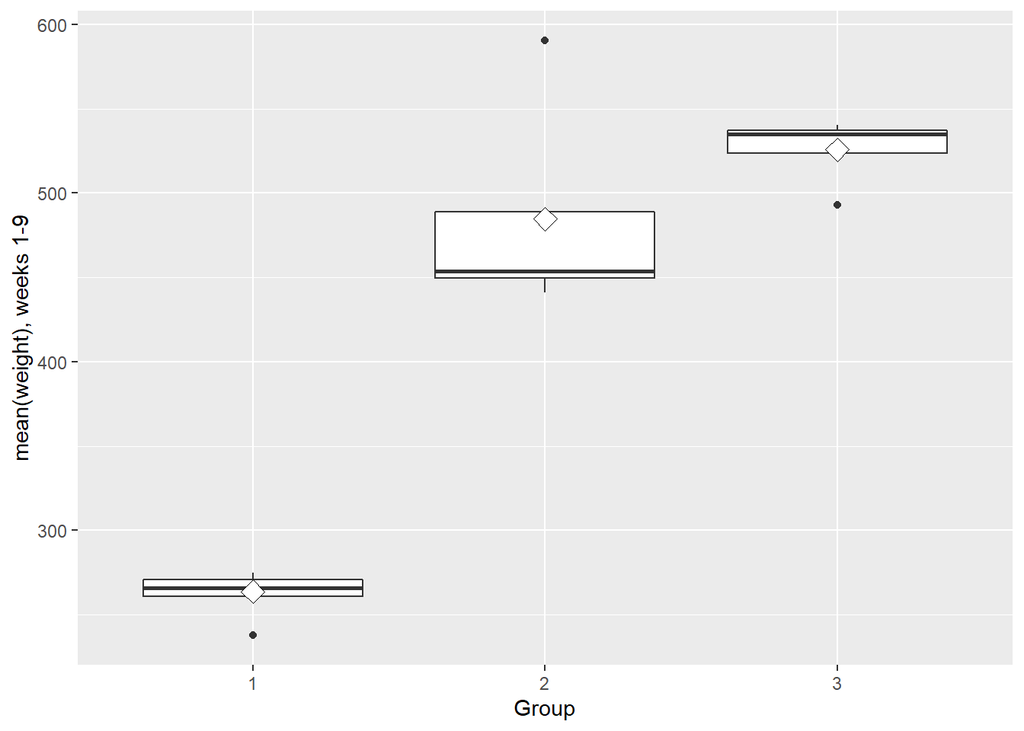

```r
#Drawing a boxplot of the mean versus treatment
ggplot(RATS_s2, aes(x = Group, y = mean)) +
  geom_boxplot() +
  stat_summary(fun = "mean", geom = "point", shape=23, size=4, fill = "white") +
  scale_y_continuous(name = "mean(weight), weeks 1-9")
```

```r
# Let's remove the most notable outlier, namely the one in Group 2.
# Creating a new data by filtering this one outlier
RATS_s2_no <- RATS_s2 %>% filter(mean<570)

dim(RATS_s2_no)
```

```
## [1] 15  3
```

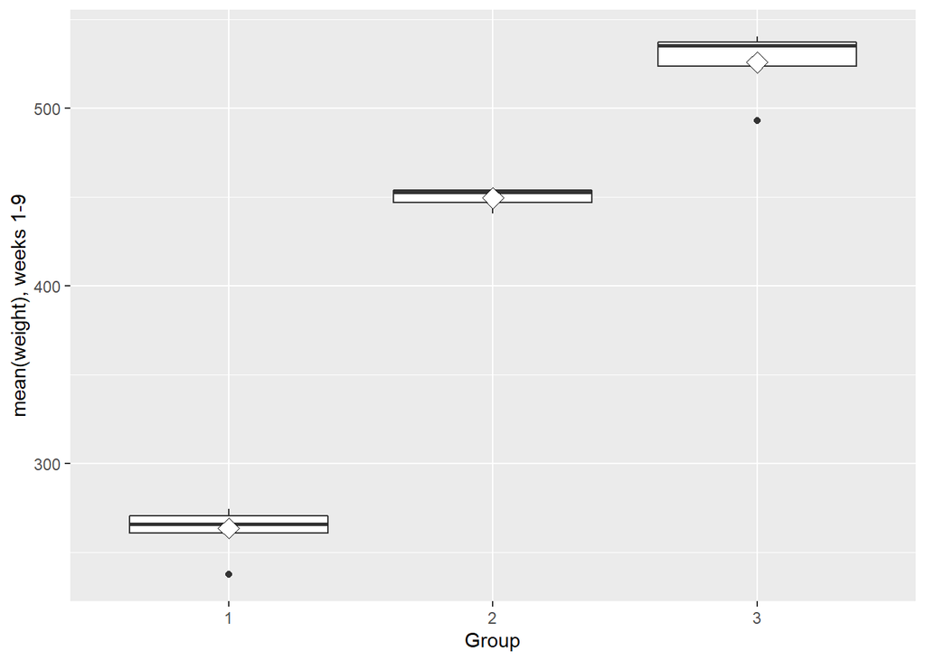

```r
#Let's draw the above plot again without the outlier
ggplot(RATS_s2_no, aes(x = Group, y = mean)) +
  geom_boxplot() +
  stat_summary(fun = "mean", geom = "point", shape=23, size=4, fill = "white") +
  scale_y_continuous(name = "mean(weight), weeks 1-9")
```

The first boxplots show three outliers, with the one in group 2 being the most notable. Indeed, the weight values are not normally distributed in group 2 in the first plot. The weight measures also appear, at least somewhat skewed in group 3.

Removing the outlier from group 2 makes a big difference as the variance in that group is now a lot smaller and the weights seem to be normally distributed. It would have likely been best to also delete the other outliers, particularly from group 3. I realized this a bit too late…

The boxplots also show clearly group differences (but they are also calculated with overall means)

### Examining the group differences with a few tests

```r
# First, let's apply an analysis of variance (Anova) to examine the groups' differences. Let's use the data without the one outlier that was removed.

res.aov <- aov(mean ~ Group, data = RATS_s2_no)
# Summary of the analysis
summary(res.aov)
```

```
##             Df Sum Sq Mean Sq F value   Pr(>F)
## Group        2 206390  103195   483.6 3.39e-12 ***
## Residuals   12   2561     213
## ---
## Signif. codes:  0 '***' 0.001 '**' 0.01 '*' 0.05 '.' 0.1 ' ' 1
```

```r
#Some of the groups differ (significant F-test value at p <.001)

#multiple comparisons, Bonferroni corrected p-value
pairwise.t.test(RATS_s2_no$mean, RATS_s2_no$Group, p.adj = "bonf")
```

```
##
##  Pairwise comparisons using t tests with pooled SD
##
## data:  RATS_s2_no$mean and RATS_s2_no$Group
##
##   1       2
## 2 8.7e-10 -
## 3 4.7e-12 5.4e-05
##
## P value adjustment method: bonferroni
```

```r
#The p-values show that all groups differ from each others when comparing group means in weight (bonferroni corrected p-value <.001)


# Let's take into account the first mean weight values in each group and run an Ancova.

#First counting the summary data without the first measurement value.

RATS_s3 <- RATS_l %>%
  filter(Time > 1) %>%
  group_by(Group, ID) %>%
  summarise( mean=mean(Weight)) %>%
  ungroup()

#removing the one outlier
RATS_s3_no <- RATS_s3 %>% filter(mean<570)

#loading in the original data in a wide format
RATS_wide <- read.table("https://raw.githubusercontent.com/KimmoVehkalahti/MABS/master/Examples/data/rats.txt",sep  ="\t",header=TRUE)

# Adding the baseline weights from the original data as a new variable to the summary data

#baseline <- RATS_wide$WD1
#RATS_s3_no <- RATS_s3_no %>%
  #mutate(baseline) # does not work since row numbers differ, the code in datacamp did't work for this either

# Fitting a linear model with the mean as the response
fit <- lm(mean ~ Group, data = RATS_s2_no) #should add baseline but can't now as it's not in the data.

# Computing the analysis of variance table for the fitted model with anova()
summary(fit)
```

```
##
## Call:
## lm(formula = mean ~ Group, data = RATS_s2_no)
##
## Residuals:
##     Min      1Q  Median      3Q     Max
## -32.886  -3.080   3.273   9.250  14.386
##
## Coefficients:
##             Estimate Std. Error t value Pr(>|t|)
## (Intercept)  263.716      5.165   51.06 2.09e-15 ***
## Group2       185.739      9.890   18.78 2.90e-10 ***
## Group3       262.080      8.945   29.30 1.56e-12 ***
## ---
## Signif. codes:  0 '***' 0.001 '**' 0.01 '*' 0.05 '.' 0.1 ' ' 1
##
## Residual standard error: 14.61 on 12 degrees of freedom
## Multiple R-squared:  0.9877, Adjusted R-squared:  0.9857
## F-statistic: 483.6 on 2 and 12 DF,  p-value: 3.387e-12
```

```r
anova(fit)
```

```
## Analysis of Variance Table
##
## Response: mean
##           Df Sum Sq Mean Sq F value    Pr(>F)
## Group      2 206390  103195   483.6 3.387e-12 ***
## Residuals 12   2561     213
## ---
## Signif. codes:  0 '***' 0.001 '**' 0.01 '*' 0.05 '.' 0.1 ' ' 1
```

```r
#The anova (without baseline) and regression shows similar results as above. I'm interested to see how this baseline should have been added!
```

A note from the book: “Baseline measurements of the outcome variable in a longitudinal study are often correlated with the chosen summary measure and using such measures in the analysis can often lead to substantial gains in precision when used appropriately as a covariate in an analysis of covariance.”

## Analysing the BPRS data (following Chapter 9 of MABS)

A short description of the data, taken from the book: The data is about “40 male subjects who were randomly assigned to one of two treatment groups and each subject was rated on the brief psychiatric rating scale (BPRS) measured before treatment began (week 0) and then at weekly intervals for eight weeks. The BPRS assesses the level of 18 symptom constructs such as hostility, suspiciousness, hallucinations and grandiosity; each of these is rated from one (not present) to seven (extremely severe). The scale is used to evaluate patients suspected of having schizophrenia.” I am assuming that higher score = higher chance of schizophrenia, or at least more schizophrenic symptoms.

```r
#First, let's ignore the repeated-measures in the data and treat each observation as independent.

#Print out a summary table of all variables
my_table2 <- tbl_summary(BPRS_l,
                        digits = all_continuous() ~ 2,
                        type = all_continuous() ~ "continuous2",
                        statistic = list(all_continuous() ~ c("{mean} ({sd})",
                                                              "{median} ({p25}, {p75})",
                                                              "{min}, {max}")))

#Add some missing elements to the table and print it out
my_table2 %>% bold_labels()
```

| **Characteristic** | **N = 360** |
| --- | --- |
| treatment |  |
| 1 | 180 (50%) |
| 2 | 180 (50%) |
| subject |  |
| 1 | 18 (5.0%) |
| 2 | 18 (5.0%) |
| 3 | 18 (5.0%) |
| 4 | 18 (5.0%) |
| 5 | 18 (5.0%) |
| 6 | 18 (5.0%) |
| 7 | 18 (5.0%) |
| 8 | 18 (5.0%) |
| 9 | 18 (5.0%) |
| 10 | 18 (5.0%) |
| 11 | 18 (5.0%) |
| 12 | 18 (5.0%) |
| 13 | 18 (5.0%) |
| 14 | 18 (5.0%) |
| 15 | 18 (5.0%) |
| 16 | 18 (5.0%) |
| 17 | 18 (5.0%) |
| 18 | 18 (5.0%) |
| 19 | 18 (5.0%) |
| 20 | 18 (5.0%) |
| weeks |  |
| week0 | 40 (11%) |
| week1 | 40 (11%) |
| week2 | 40 (11%) |
| week3 | 40 (11%) |
| week4 | 40 (11%) |
| week5 | 40 (11%) |
| week6 | 40 (11%) |
| week7 | 40 (11%) |
| week8 | 40 (11%) |
| bprs |  |
| Mean (SD) | 37.66 (13.66) |
| Median (IQR) | 35.00 (27.00, 43.00) |
| Range | 18.00, 95.00 |
| week |  |
| 0 | 40 (11%) |
| 1 | 40 (11%) |
| 2 | 40 (11%) |
| 3 | 40 (11%) |
| 4 | 40 (11%) |
| 5 | 40 (11%) |
| 6 | 40 (11%) |
| 7 | 40 (11%) |
| 8 | 40 (11%) |

```r
head(BPRS_l,41) #The summary table shows that there are 20 subject but there are actually 40, the ID numbers are from 1-20 from both treatment groups and the groups have different people!
```

```
##    treatment subject weeks bprs week
## 1          1       1 week0   42    0
## 2          1       2 week0   58    0
## 3          1       3 week0   54    0
## 4          1       4 week0   55    0
## 5          1       5 week0   72    0
## 6          1       6 week0   48    0
## 7          1       7 week0   71    0
## 8          1       8 week0   30    0
## 9          1       9 week0   41    0
## 10         1      10 week0   57    0
## 11         1      11 week0   30    0
## 12         1      12 week0   55    0
## 13         1      13 week0   36    0
## 14         1      14 week0   38    0
```

[output cut: 27 more lines]

```r
str(BPRS_l)
```

```
## 'data.frame':    360 obs. of  5 variables:
##  $ treatment: Factor w/ 2 levels "1","2": 1 1 1 1 1 1 1 1 1 1 ...
##  $ subject  : Factor w/ 20 levels "1","2","3","4",..: 1 2 3 4 5 6 7 8 9 10 ...
##  $ weeks    : chr  "week0" "week0" "week0" "week0" ...
##  $ bprs     : int  42 58 54 55 72 48 71 30 41 57 ...
##  $ week     : int  0 0 0 0 0 0 0 0 0 0 ...
```

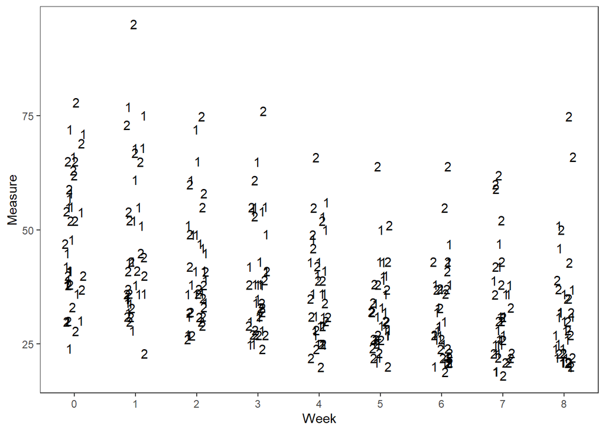

```r
#Let's recode the subject values so that everyone has individual "id". Maybe this helps later on with some errors I got in the plots (it did, yay!)
BPRS_l_test <- BPRS_l %>%
  mutate(subject = ifelse(as.character(treatment) == "2", recode(as.character(subject), "1" = 21, "2" = 22, "3" = 23, "4" = 24, "5" = 25, "6" = 26, "7" = 27, "8" =28, "9"=29, "10"=30, "11"=31, "12"=32, "13"=33, "14"=34, "15"=35, "16"=36, "17"=37, "18"=38, "19"=39, "20"=40), subject))


#Let's start with plotting the data. Let's note group partnerships but ignore the longitudinal nature of the data for now.

# Drawing the measures against week plots
#
#First, let's make a scatterplot. And add some jitter to maybe see the overlapping observations a bit better.
p1 <- ggplot(BPRS_l, aes(x = week, y = bprs, group = subject))
p2 <- p1 + geom_text(aes(label = treatment), position=position_jitter(width=0.15,height=0.1))
p3 <- p2 + scale_x_continuous(name = "Week", breaks = seq(0, 8, 1))
p4 <- p3 + scale_y_continuous(name = "Measure")
p5 <- p4 + theme_bw()
p6 <- p5 + theme(panel.grid.major = element_blank(), panel.grid.minor = element_blank())
p6
```

```r
# Still ignoring the repeated-measures structure of the data, let's fit a multiple linear regression model where bprs is response and week and treatment are explanatory variables.

# create a regression model BPRS_reg
BPRS_reg <- lm(bprs ~ week + treatment, data=BPRS_l)

# print out a summary of the model
summary(BPRS_reg)
```

```
##
## Call:
## lm(formula = bprs ~ week + treatment, data = BPRS_l)
##
## Residuals:
##     Min      1Q  Median      3Q     Max
## -22.454  -8.965  -3.196   7.002  50.244
##
## Coefficients:
##             Estimate Std. Error t value Pr(>|t|)
## (Intercept)  46.4539     1.3670  33.982   <2e-16 ***
## week         -2.2704     0.2524  -8.995   <2e-16 ***
## treatment2    0.5722     1.3034   0.439    0.661
## ---
## Signif. codes:  0 '***' 0.001 '**' 0.01 '*' 0.05 '.' 0.1 ' ' 1
##
## Residual standard error: 12.37 on 357 degrees of freedom
## Multiple R-squared:  0.1851, Adjusted R-squared:  0.1806
## F-statistic: 40.55 on 2 and 357 DF,  p-value: < 2.2e-16
```

```r
#Let's NOT include a week*treatment interaction term into the model,
#not smart since the model structure has repeated measures, i.e. data points are not independent!
#BPRS_reg2 <- lm(bprs ~ week * treatment, data=BPRS_l)
```

Both groups seem to have very overlapping values in the scatter plot, i.e. there does not seem to be, at least no clear, differences between the treatment groups.

The linear model (regression model) supports this view since treatment2 does not differ significantly from treatment1 (p > 0.1). Treatment week seems to have a negative effect on symptoms (p <.001) but we need to remember that the datapoints are not actually uncorrelated with each other (measurements from same individuals)